# lab03 - Relatório

02/05/2015

```r
library(ggplot2)
library(magrittr)
library(tidyr)
library(dplyr)
library(jpeg)
library(tree)
```

# Laboratório III - Recuperação de imagem

## Objetivo

- Verificar qual modelo entre **regressão linear** e **árvores de decisão** é o mais adequado para recuperar a o componente azul da imagem **purple_wave.jpg**.
- Verificar qual modelo entre **regressão linear** e **árvores de decisão** é o mais adequado para recuperar a o componente azul da imagem **xadrez_colorido.jpg**.

## Preparação do Banco de dados

```r
# a) carrega uma imagem jpeg no R
img <- readJPEG("data/purple_wave.jpg")

# b) transforma o array da imagem em data.frame com infos de posicao (x,y) e cor (r,g,b)
# dimensões da imagem
img_dim <- dim(img)

# RGB para data.frame
img_df <- data_frame(
  x = rep(1:img_dim[2], each = img_dim[1]),
  y = rep(img_dim[1]:1, img_dim[2]),
  r = as.vector(img[,,1]),
  g = as.vector(img[,,2]),
  b = as.vector(img[,,3])) %>%
  mutate(cor = rgb(r, g, b), id = 1:n())
```

```r
# para reprodução
set.seed(1)

# Parte 1) x, y, r, g
base_teste <- img_df %>%
  sample_frac(3/5) %>%        # separando 3/5 do banco
  mutate(b_backup = b,        # backup do azul original
         b = 0,               # retirando o azul da imagem
         cor = rgb(r, g, b))  # cor da imagem sem o azul

# Parte 2) x, y, r, g, b
base_treino <- img_df %>%
  filter(!id %in% base_teste$id)
```

Veja como fica a **imagem original sem o azul** e como é o **azul original isolado**.

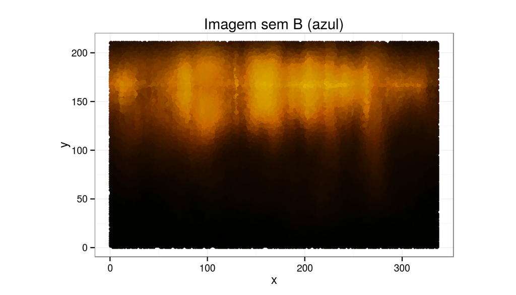

```r
# Um pedaço (60%) da imagem, sem azul
ggplot(base_teste) +
  geom_point(aes(x=x, y=y), colour=base_teste$cor) +
  labs(x = "x", y = "y", title = "Imagem sem B (azul)") +
  coord_fixed(ratio = 1) +
  theme_bw()
```

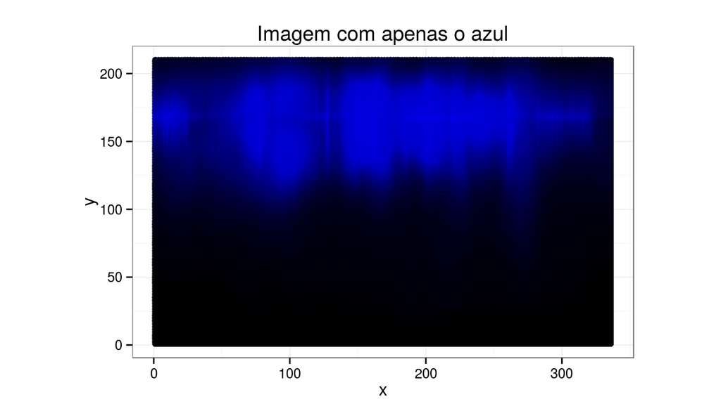

```r
# 100% da imagem, com apenas o azul
ggplot(img_df) +
  geom_point(aes(x=x, y=y), colour=rgb(0, 0, img_df$b)) +
  labs(x = "x", y = "y", title = "Imagem com apenas o azul") +
  coord_fixed(ratio = 1) +
  theme_bw()
```

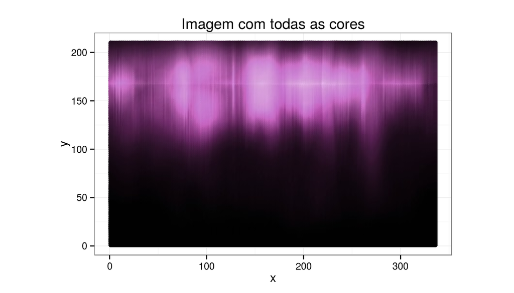

```r
# 100% da imagem, com as cores originais
ggplot(img_df) +
  geom_point(aes(x=x, y=y), colour=img_df$cor) +
  labs(x = "x", y = "y", title = "Imagem com todas as cores") +
  coord_fixed(ratio = 1) +
  theme_bw()
```

Seu objetivo é recuperar a cor azul da `base_teste`.